# Packages and Documentation

Naomi Tague

May 25, 2019

- code (zip)

# What we’ve learned so far

- how to make a function
- how to generate data for a function
  - by sampling from know distributions (e.g normal)
  - sampling from a sequence with assigned probablities
- how to repeat our function for multiple parameter values
- how to create data structures to store the output of multiple uses of the function

## A bit more on Looping

Loops - similar to apply but more general

```r
library(tidyverse)
# repeat statement
a=0
for (i in 1:5) {
 a = a+i
}
a
```

```
## [1] 15
```

```r
# read in come data
clim = read.table("clims.txt", header=T)
head(clim)
```

```
##       date       tmin       tmax   rain year month day   wy
## 1 01/01/42 -14.444444 -5.0000000 20.828 1942     1   1 1942
## 2 01/02/42 -14.444444 -0.5555556  0.000 1942     1   2 1942
## 3 01/03/42 -10.000000 -1.1111111  0.000 1942     1   3 1942
## 4 01/04/42 -10.000000  0.5555556  0.000 1942     1   4 1942
## 5 01/05/42  -9.444444  2.2222222  0.000 1942     1   5 1942
## 6 01/06/42  -7.777778  3.8888889  0.000 1942     1   6 1942
```

```r
# use loops to find the maximum speed
maxrain = 0
for ( i  in 1:length(clim$rain)) {
  maxrain = ifelse(clim$rain[i] > maxrain, clim$rain[i], maxrain)
}

maxrain
```

```
## [1] 256.286
```

```r
max(clim$rain)
```

```
## [1] 256.286
```

```r
# apply's are R's internal loops - FAST
# by column
all_max = apply(select(clim,-date), 2, max)
all_max
```

```
##       tmin       tmax       rain       year      month        day
##   26.11111   32.77778  256.28600 2016.00000   12.00000   31.00000
##         wy
## 2016.00000
```

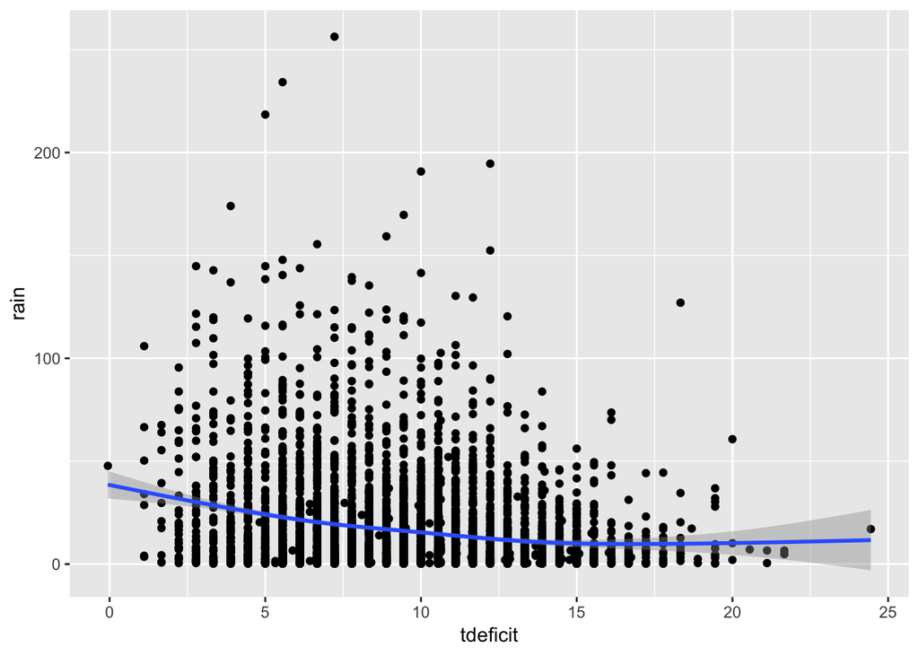

```r
# by row
clim$tavg = apply(clim[,c("tmin","tmax")],1,mean)


# sometime loops are needed
# generate a time sequence that returns tmax-tmin (correlated with humidity) on the day before it rains - and 0 otherwise

# often with loops you need to create an object to store results
clim$tdeficit = rep(NA, times=nrow(clim))

# I'll start on the second day ...why?
for ( i in 2:nrow(clim)) {
  clim$tdeficit[i] = ifelse(clim$rain[i] > 0,clim$tmax[i-1]-clim$tmin[i-1], NA)
}

ggplot(clim,aes(tdeficit,rain))+geom_point()+geom_smooth(geom="line")
```

```r
# create a loop that computes a temperature risk that is 1 if
# the averge of 3 days (1 before, current and after) of daily maximum tempeature is greater than 20
# 0.5 if average is greater than 15
# 0 otherwise
# and is always zero when it is raining on that day


# turn this into a temperature risk function, that takes as input the time series of maximum temperature and returns risk
```

Loops can be “nested” on loop in side the other

Exampe: Calculate NPV or a range of different interest rates and a range of damages that may be incurred 10 years in the future

Steps

- define inputs (interest rates, damages)
- define output (NPV)
- write the function
- create a data structure to store results where we vary both interest rates and damages
- use nest for loops to fill in the data structure

```
## [1] 16.39089
```

```
##         V1       V2       V3       V4       V5       V6       V7
## 1 22.63217 21.54168 20.50871 19.52996 18.60235 17.72297 16.88910
## 2 29.87447 28.43502 27.07149 25.77955 24.55510 23.39432 22.29362
## 3 82.38111 78.41172 74.65170 71.08905 67.71255 64.51161 61.47634
## 4 21.72689 20.68001 19.68836 18.74876 17.85825 17.01405 16.21354
```

```
##        0.01    0.015     0.02    0.025     0.03    0.035     0.04
## 25 22.63217 21.54168 20.50871 19.52996 18.60235 17.72297 16.88910
## 33 29.87447 28.43502 27.07149 25.77955 24.55510 23.39432 22.29362
## 91 82.38111 78.41172 74.65170 71.08905 67.71255 64.51161 61.47634
## 24 21.72689 20.68001 19.68836 18.74876 17.85825 17.01405 16.21354
```

```
##   discount      npv
## 1     0.01 22.63217
## 2     0.01 29.87447
## 3     0.01 82.38111
## 4     0.01 21.72689
## 5    0.015 21.54168
## 6    0.015 28.43502
```

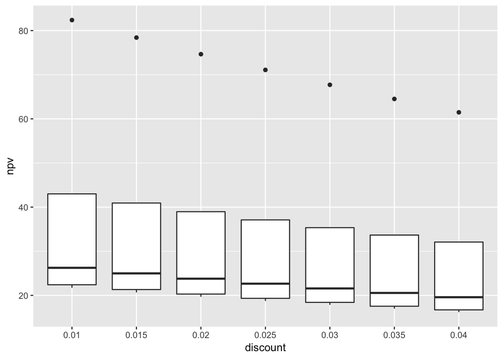

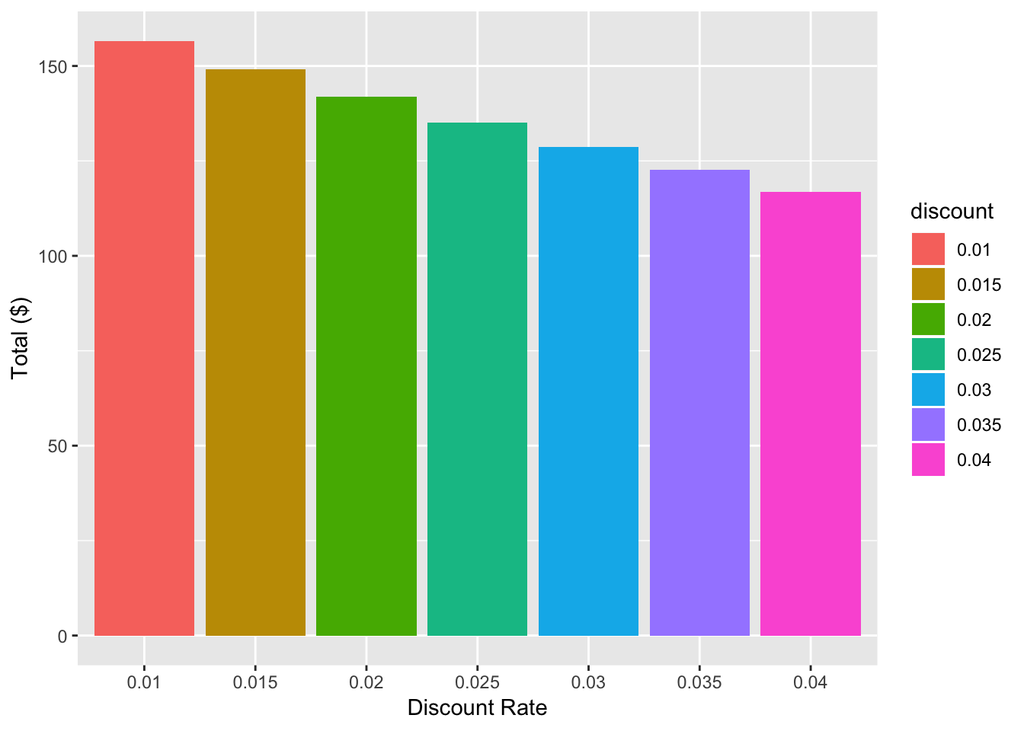

Some other types of loops

- while useful for repeating until a condition is met

Example if a metal toxin in a lake increases by 1% per year, how many years will it take for the metal level to be greater than 30 units, if toxin is current at 5 units

```r
# accumulate pollutant until a threshold - how many years does it take

# initial conditions
yr=1
pollutant_level = 5

# loop
while (pollutant_level < 30)   {
  # increase pollutant
pollutant_level = pollutant_level + 0.01* pollutant_level
# keep track of time
yr = yr + 1
}

pollutant_level
```

```
## [1] 30.2788
```

```r
yr
```

```
## [1] 182
```

```r
# while loop dangers

# use a while loop to determine the discount rate at which the net pressent value of 1000 in 20 years is less than 200
# start with a discount rate of 0.01 and increase in steps of 0.01
```

## Data types

All programing languages use data-types, or structures to hold information

- integer
- floating point/ real / numeric
- character
- string

Often data types are multi-dimensional Some useful ones in R

- vector
- matrix
- data frame
- tibble
- factors
- lists

Programming often involves selecting and building data structures. Like the **res** matrix we built last class to hold the results from our **for** loop

Good data structures are

- as simple as possible
- easy to understand (readable names)
- easy to manipulate
- easy to visualize

# Factors

something that has different **classes** or **groups** useful for doing calculations with categories

Here’s an example:

First lets look at a standard numeric vector

```r
a = c(1.3, 1, 4, 1.3, 22)
# compute the mean
mean(a)
```

```
## [1] 5.92
```

What if **a** is a factor

What do commands like **mean** do

```r
a = as.factor(a)
# compute the mean
mean(a)
```

```
## [1] NA
```

```r
#why? lets look
a
```

```
## [1] 1.3 1   4   1.3 22
## Levels: 1 1.3 4 22
```

We can use **summary** with factors to get frequencies in each category (or “level” )

```r
# create vector of possible fish
possible.fish = c("salmon","steelhead","shark","tuna","cod")

# we can use sample to simulate a random recording of catch by fisherman, lets say we pick 20 fish from the net

catch1 = sample(possible.fish, size=20, replace=T)
# because possible.fish was a factor catch1 will be a factor
catch1
```

```
##  [1] "salmon"    "cod"       "salmon"    "salmon"    "cod"
##  [6] "shark"     "tuna"      "salmon"    "tuna"      "shark"
## [11] "tuna"      "cod"       "salmon"    "cod"       "tuna"
## [16] "shark"     "salmon"    "salmon"    "shark"     "steelhead"
```

```r
summary(catch1)
```

```
##    Length     Class      Mode
##        20 character character
```

```r
# if we want summary to be more useful - make this a factor
catch1 = as.factor(catch1)


# to quickly get frequencies of different fish and to plot
summary(catch1)
```

```
##       cod    salmon     shark steelhead      tuna
##         4         7         4         1         4
```

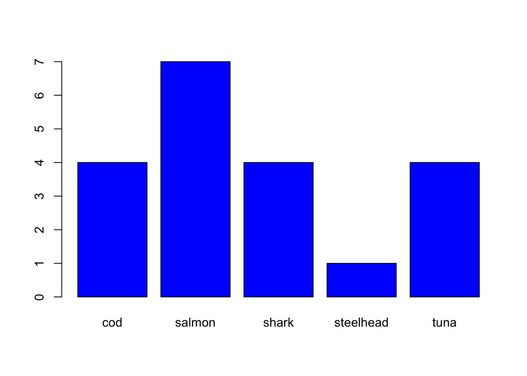

```r
plot(catch1, col="blue")
```

```r
# we can also use summary to explore and return information about the distribution
# mean frequency of a particular type of fish
mean(summary(catch1))
```

```
## [1] 4
```

```r
# maximum frequency
max(summary(catch1))
```

```
## [1] 7
```

```r
# which fish was most frequently caught
which.max(summary(catch1))
```

```
## salmon
##      2
```

```r
#to get just the name
names(which.max(summary(catch1)))
```

```
## [1] "salmon"
```

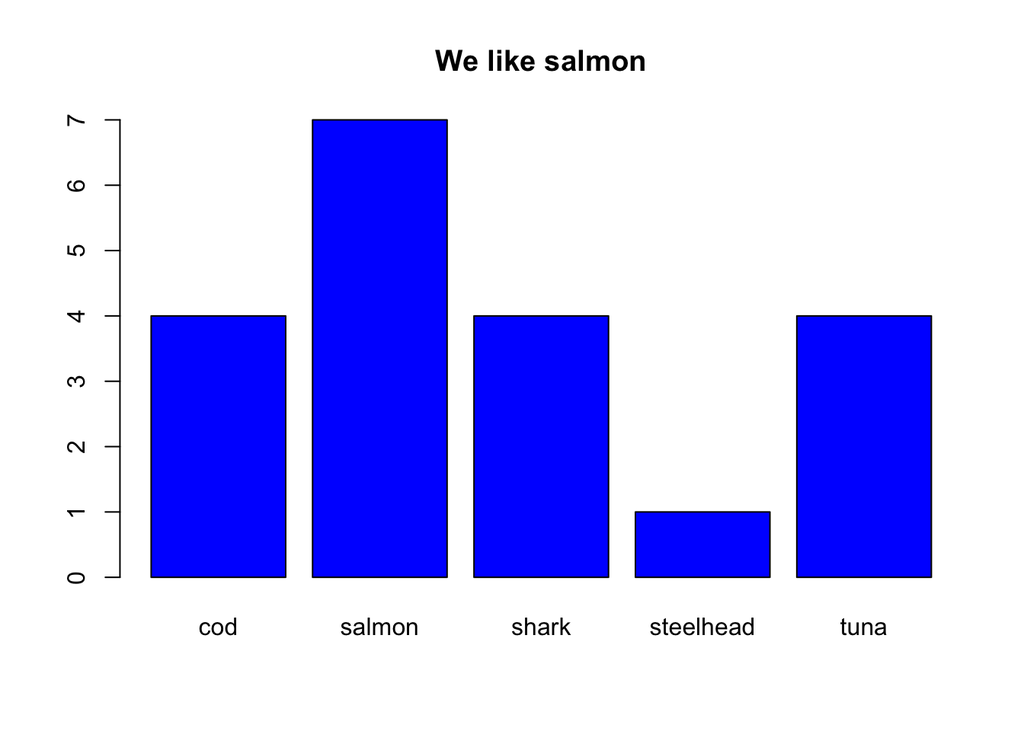

```r
# use results for creating text
# sprintf creates a string %s mean use what ever is after the , to fill in a string
plottitle=sprintf("We like %s", names(which.max(summary(catch1))))

plot(catch1, col="blue", main=plottitle)
```

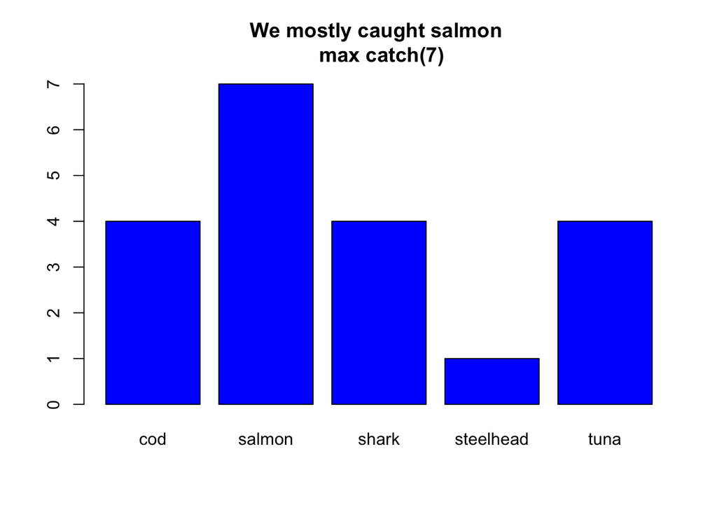

```r
# you can also add numbers to the string
plottitle=sprintf("We mostly caught %s \n max catch(%d)", names(which.max(summary(catch1))), max(summary(catch1)))
plot(catch1, col="blue", main=plottitle)
```

```r
#How do you figure out the rarest fish in our simulated ocean

# bigger challenge how would use pre-assign probabilities to different fish and then generate your ocean, hint look at help page for sample
```

# Aside **sprintf**

## Functions with factors

Lets generate a function that makes use of categorical data species diversity is a good example

"Simpson’s Index (D) measures the probability that two individuals randomly selected from a sample will belong to the same species

See [Simpson Biodiversity](http://www.countrysideinfo.co.uk/simpsons.htm)

```r
source("esm237examplesS18/R/compute_simpson_index.R")
compute_simpson_index
```

```
## function (species, index.type = "a")
## {
##     if (index.type == "a") {
##         species = as.factor(species)
##         tmp = (summary(species)/sum(summary(species)))^2
##         diversity = sum(tmp)
##     }
##     if (index.type == "b") {
##         diversity = 4
##     }
##     return(diversity)
## }
```

```r
possible.fish = as.factor(c("salmon","steelhead","shark","tuna","cod"))
# simulate a random recording of catch by fisherman


# note here is answer to above challenge
catch1 = sample(possible.fish, size=10, prob = c(0.2, 0.2, 0.1, 0.1, 0.4), replace=T)
# lets create a test case that should have low diversity, by repeating the same thing
catch2 = c(rep("salmon", times=10), rep("cod", times=10))

compute_simpson_index(catch1)
```

```
## [1] 0.42
```

```r
compute_simpson_index(catch2)
```

```
## [1] 0.5
```

Repeat for the alternative Simpson Diversity Index Test on the **fish.txt**

Divide by zero - one of the most common errors!

Sometimes you don’t want factors and R thinks something should be How to change back? **as.numeric** makes sense …but

```r
a = as.factor(c(1.3, 1, 4, 1.3, 22))
#sum(a)

# try to make a numeric version from the factor
b = as.numeric(a)
sum(b)
```

```
## [1] 12
```

```r
b
```

```
## [1] 2 1 3 2 4
```

```r
# better
b = as.character(a)
b = as.numeric(b)
b
```

```
## [1]  1.3  1.0  4.0  1.3 22.0
```

```r
sum(b)
```

```
## [1] 29.6
```

## Returning multiple things from a function

In R, to do this we use LISTS

- Lists are the most “informal” data structures in R
- List are really useful for keeping track of and organizing groups of things that are not all the same
- A list could be a table where number of rows is different for each column
- A list can have numeric, character, factors all mixed together
- List are often used for returning more complex information from function (e.g. lm)

```r
# make a list
sale = list(id=2, quality="high", contents=c("apple","cherry"), cost=c(4,5))
sale
```

```
## $id
## [1] 2
##
## $quality
## [1] "high"
##
## $contents
## [1] "apple"  "cherry"
##
## $cost
## [1] 4 5
```

```r
#ways to access elements
sale$id
```

```
## [1] 2
```

```r
sale$what
```

[output not shown]

```r
# you can also access by list item number
# the [x] denotes the xth item in the list
sale[[3]]
```

```
## [1] "apple"  "cherry"
```

```r
sale[["contents"]]
```

```
## [1] "apple"  "cherry"
```

```r
# how do you get the second element in the vector that has the contents
# there are two ways


# add to a list
sale$location = "Farmers market"
sale
```

```
## $id
## [1] 2
##
## $quality
## [1] "high"
##
## $contents
## [1] "apple"  "cherry"
##
## $cost
## [1] 4 5
##
## $location
## [1] "Farmers market"
```

```r
# or remove
sale$location = NULL
sale
```

```
## $id
## [1] 2
##
## $quality
## [1] "high"
##
## $contents
## [1] "apple"  "cherry"
##
## $cost
## [1] 4 5
```

```r
# some tricky things
# correct accessing items in list
sale$cost
```

```
## [1] 4 5
```

```r
sale[[4]]
```

```
## [1] 4 5
```

```r
# works but
#sale[4]


sum(sale$cost)
```

```
## [1] 9
```

```r
sum(sale[[4]])
```

```
## [1] 9
```

So why use these complex data types?

R functions return *lists* and useful when you don’t know how many rows you will need in a data frame or matrix

consider *lm*

```r
# read in some streamflow data
sage = read.table("sagedata.txt", header=T)
names(sage)
```

```
## [1] "month"  "year"   "day"    "wy"     "tavg"   "precip" "trans"  "psn"
```

```r
# sum to water year
sage_wy = sage %>% group_by(wy) %>% summarize(tavg=mean(tavg), precip=sum(precip), trans=sum(trans), psn=sum(psn))

# regress photosynthesis (psn) against precip
res = lm(psn~precip+wy, data=sage_wy)
summary(res)
```

```
##
## Call:
## lm(formula = psn ~ precip + wy, data = sage_wy)
##
## Residuals:
##      Min       1Q   Median       3Q      Max
## -0.52130 -0.15674  0.01208  0.16764  0.35261
##
## Coefficients:
##               Estimate Std. Error t value Pr(>|t|)
## (Intercept) 68.9810967 14.1619834   4.871 8.14e-05 ***
## precip       0.0001751  0.0001200   1.459    0.159
## wy          -0.0341703  0.0070816  -4.825 9.07e-05 ***
## ---
## Signif. codes:  0 '***' 0.001 '**' 0.01 '*' 0.05 '.' 0.1 ' ' 1
##
## Residual standard error: 0.2388 on 21 degrees of freedom
## Multiple R-squared:  0.5354, Adjusted R-squared:  0.4911
## F-statistic:  12.1 on 2 and 21 DF,  p-value: 0.0003196
```

```r
#lm returns a list so we can look at the different elements

res$coefficients
```

```
## (Intercept)      precip          wy
## 68.98109672  0.00017512 -0.03417029
```

```r
res[["coefficients"]]
```

```
## (Intercept)      precip          wy
## 68.98109672  0.00017512 -0.03417029
```

```r
res[["call"]]
```

```
## lm(formula = psn ~ precip + wy, data = sage_wy)
```

We can use *lists* to return multiple,diverse pieces of information from our functions Lets start with diversity - many be want to know a bit more about the dataset

- Simpson diversity
- most frequent species
- number of distinct species

```r
# repeat with a list
source("esm237examplesS18/R/computediversity.R")

computediversity
```

```
## function (species)
## {
##     species = as.factor(species)
##     tmp = (summary(species)/sum(summary(species)))^2
##     diversity = 1 - sum(tmp)
##     nspecies = length(summary(species))
##     tmp = which.max(summary(species))
##     dominant = names(summary(species)[tmp])
##     return(list(num = nspecies, simpson = diversity, dominant = dominant))
## }
```

```r
computediversity(catch1)
```

```
## $num
## [1] 5
##
## $simpson
## [1] 0.58
##
## $dominant
## [1] "cod"
```

```r
computediversity(catch2)
```

```
## $num
## [1] 2
##
## $simpson
## [1] 0.5
##
## $dominant
## [1] "cod"
```

In class: Try adding to your diversity function: return the rarest species;

We can also use parameters to determine flow control in a function

```
## $summer
## [1] 0.02982467
##
## $winter
## [1] 0.06705754
```

```
## $summer
## [1] 0.642605
##
## $winter
## [1] 0.657214
```

What you’ve learned

- common data types
- common flow control approaches
- returning multiple items from a function

# Definitions

- **Package**: An extension of the R base system with code, data and documentation in standardized format.
- **Library**: A directory containing installed packages.
- **Repository**: A website providing packages for installation.
- **Source**: The original version of a package with human-readable text and code.
- **Binary**: A compiled version of a package with computer-readable text and code, may work only on a specic platform.
- **Base packages**: Part of the R source tree, maintained by R Core.
- **Recommended packages**: Part of every R installation, but not necessarily maintained by R Core.
- **Contributed packages**: All the rest. This does not mean that these packages are necessarily of lesser quality than the above, e.g., many contributed packages on CRAN are written and maintained by R Core members. They simply try to keep the base distribution as lean as possible.
- **User packages**: Packages that you write, share with a smaller community - not downloadable from CRAN, but can be downloaded (or sent as a zip file) and loaded into R

# Why make packages

- to easily share functions and data with others with R-specific documentation
- have a set of tools (functions) that you often use, that can be easily loaded
- be part of the R community

# Installing User Packages

- looks similar to CRAN packages
- uncompiled (they can be compiled but not always) so you can **see** the code

You can load my package *esm237examplesS18* by

- downloading *esm237examplesS18.tar.gz*
  - DON’T UNZIP
- install from a *package archive*
- *library(esm237examples)*
- to make sure it works,try the following
  - *help(compute_NPV)*
  - *spring_summary*
  - note that this shows you the code used to implement spring.summary

# Making your own packages

First lets review the format for writing functions

- documentation (we will say more on this later)
- function definition
- named **something.R**
- dont’ have ANYTHING else in your **something.R** file
- to see an example look at spring.summary.R on github`
- Make sure you have version controll set up to work with R  
  [help on setting git with R](https://support.rstudio.com/hc/en-us/articles/200532077?version=1.1.463&mode=desktop)

## Steps for starting a package

- Think of a name for your package, it should be descriptive of the many related functions that you will store there * mine will be **esm237examplesS18**
- Back in Rstudio, start a new project, using the same name for the project as your package name
  - choose the option in package creation to ** create a package **
  - make sure that the **path** to this directory is not in the course directory, or other directory that is already under version control (git)
  - link to existing Github site
- If you already have an R function you can add it here
  - make sure your function is named **something.R** and follows the format for functions that we have been using
  - try adding one of the functions that you created to compute diversity
- Install libraries **devtools** and **roxygen2** from CRAN
- Link with a git repository - see project set up

You will notice that this creates a directory structure that looks something like this

R Package Directory

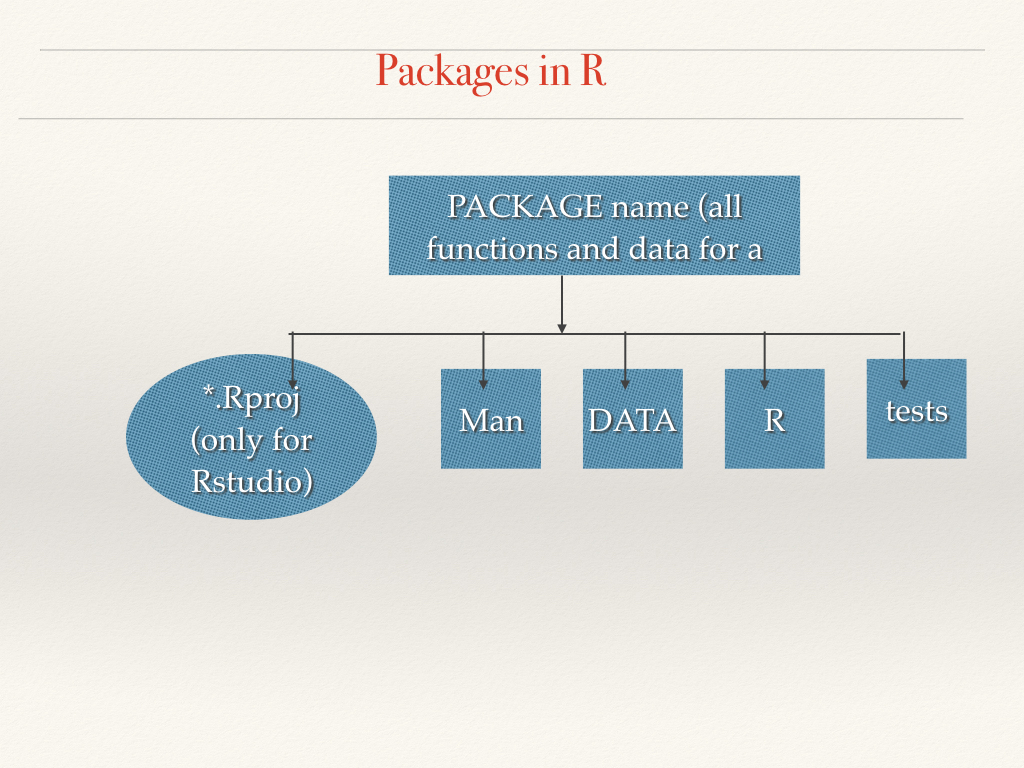

You R function will be stored in the **R** subdirectory IF **man** and **data**, **tests** subdirectories are not created - created them

This package (e.g **esm237examplesS18**) directory structures store your code and documentation; that is easy for R to read. It include

- A file DESCRIPTION with descriptions of the package, author, and license conditions
- A man/ subdirectory of documentation files.
- An R/ subdirectory of R code.
- A data/ subdirectory of datasets.

Inclass Exercise: Make a change to your R function, save it, then re-installusing either menu: * *Build* - *Build and Reload* * *load_all()* command from command line

This will Load your functions in your package that is under-development

You can edit DESCRIPTION to add useful information particularly if you are going to share this package

It is useful to keep an Rmarkdown file or R script that lets you run your function - this should be stored *outside* of the package directory

Here’s an example

Use of spring.summary

```r
# load "stuff" in your package including R
load_all()
#read in data
clim=read.table("../clim.txt", header=T)

# run a function in the package
result = spring_summary(clim)
result

# notice
help(spring_summary)
```

Try this: * create a Rmarkdown file that you will use for using functions in your package * save it in a directory above where you are creating your package * in the Rmarkdown, provide code to generate some sample data, save it and read it in and apply your function

# Link back to Github

- On *Github* create a new repository
- Back in Rstudio, in your project, in a *shell* window in your R studio, do the following
- make sure you are in the project directory (*pwd*)
- execute the following command

*git remote add origin ‘http link from git’*

then

- *git pull origin master*
- *git push -u origin master*

Now your Project is linked with github and you can push/pull changes to github repo (when you are ready) Keep in mind that you can work locally to *play*

Two setps to send stuff to github repo

- commit locally
- push to git hub
- if you are collaborating or working on different machines its also good to pull regularly

# Documentation

- There is a standard format for documentation that can be read by automatic programs (roxygen2) - an R package that generate “standard” R documentation - manual or help pages
- These automated approaches for building documentation (like roxygen2) and meta data (descriptions of data sets) are increasingly common - so you should get into the practice of being structured in your approach to documentation
- We will use the conventions that work with roxygen2 - and then use this program to generate formal R documentation. Roxygen is similar to Doxygen which is used for C code…so its a widely used format

Documentation is placed at the top of the *something.R* file all lines start with *#'*

Here’s an example

Documentation example

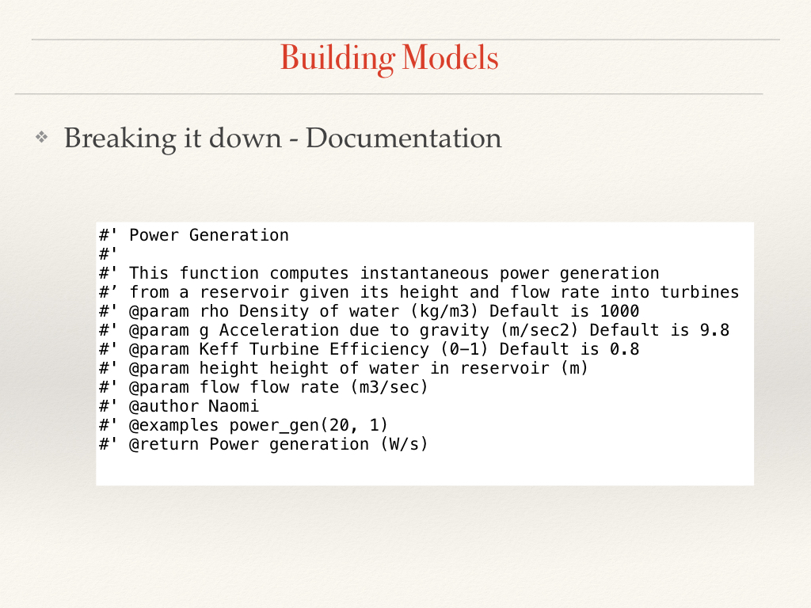

##Three Parts to R documentation * **Description** - summary of what your model/function does * **Tagged (using special “key” words)**

Here are some examples there are many others

- *@param* inputs/parameter description
- *@return* what your function returns (outputs)
- *@example* how to use it
- *@references* citations or urls
- *@author* YOU

(you don’t need all of these and there are more tags, but start with at least param and return, example is a good idea

- **Within function** Any use of # within the body of the function (this does not get used in the Help)

## Creating Help pages

If you use this approach then *roxygen* can generate help pages - here are the steps

- Add the documentation information as described above to your function
- Save your function, make sure that it is in the *R/* subdirectory your project directory eg *esm237examples/R/test.R*
- Set your working directory to your project directory
- Make sure you’ve run *library(roxygen2)*
- Run *document* from Rstudio drop down menu or *document()* from command line - this will create documentation for ANY of the *.R files you have in the R directory (you can have many of them)
- try *help(test.R)* to see the results
- you don’t have to re-run document the next time your run R, to load (used when you have project and are developing your new package), if it is another package this will be part of the install
- if you change one of your R functons or the documentation, you need to build and re-load
- try adding another small function - something simple with documentation

# Adding Data to your package

## Accessing existing data stored with packages

To access a dataset that has been stored with a package

**data(name)**

There are numerous data sets stored with the base R package try `data(CO2)'`help(CO2)’

This is a data set on carbon dioxide uptake in plants - note that it always has help documentation that is similar to functions

You can then refer to that dataset as an object in your workspace

## Storing your own data

*have the dataset (e.g clim) in your workspace

- set working directory to one level above your package directory
- save the data to the data subdirectory of your package using:
  - use_data(name, pkg=“packagename”)
  - eg. *use_data(clim, pkg=esm237examplesS18)*
- dataset will be stored as data/name.rda in your package

## Documenting Data sets for Packages

Here’s an example

Data Documentation example

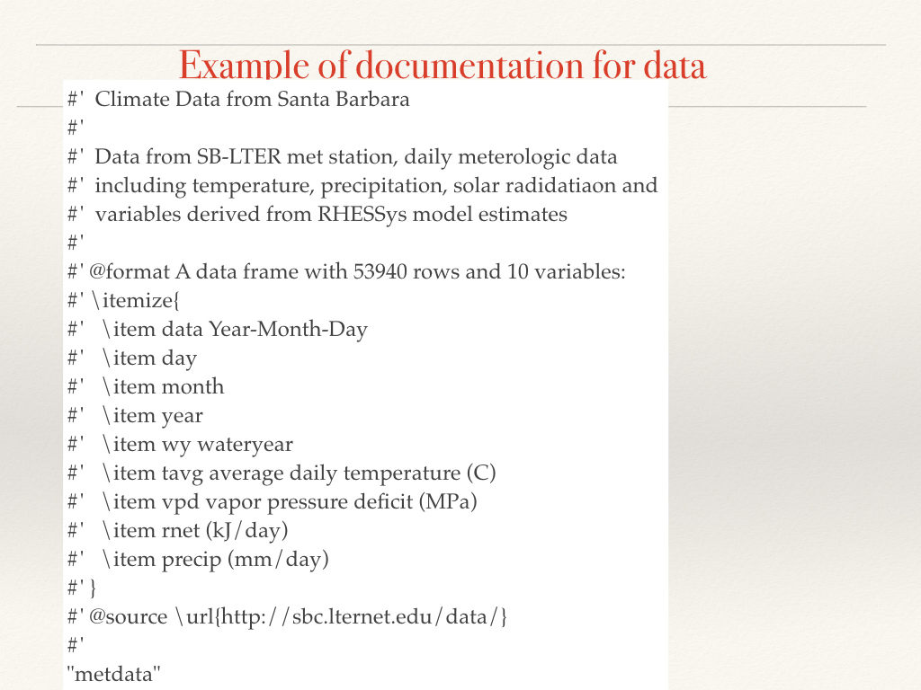

### Steps for documenting data sets

- store documentation as a file (dataname.R) (e.g **R/clim.R**) save that file in the R subdirectory of your package
- this file will contain ONLY the documentation for the data set
- when you rebuild or run document - documentation will be created with roxygen2
- format is similar to documentation for function but you will use some different identifiers for documentation including:
  - title
  - descripition
  - @format
  - @source
  - \itemize - itemize allows you to describe the data (see example above)
  - end the file with the name of your dataset (in data directory) in quotes
  - set your working directory to your project directory
  - once you’ve generated the documentation - run *document(dataname)* and try *help(dataname)* to test

Generate some data and store it with your package

# Giving the package to others

When you work on the defining the package you use the project of the same name To give the package to others - (who will simply be using it)

- build a source package (see build directory)
- this will create an *.gz file that you can distribute
- the user will then **install** this package in order to have access to functions and data in your package